# Final_Project

## download csv file in dropbox and load into

```r
#install.packages('tidyverse')
#install.packages("mice")
#library(corrplot)
#library(gridExtra)
#library(DT)
#ibrary(leaflet)
#library(htmltools)
#install.packages('dplyr')
#install.packages("magrittr")
#install.packages("corrplot")
library(magrittr)
library(data.table)
library(bit64)
library(tidyverse)
library(lubridate)
library(mice)
library(corrplot)
library(data.table)
```

```r
# Need to run the download if you did not download the source file from dropbox
 #download.file("# Need to run the download if you did not download the source file from dropbox
#download.file("https://www.dropbox.com/s/g9boi9h61t15q61/FinalProject_House_properties.csv?raw=1",
     #       "FinalProject_House_properties.csv" )
```

```r
properties <- read.csv('FinalProject_House_properties.csv', row.names = NULL)
```

### load data from sqllit at github

```r
# Need to run the download if you did not download the source file from dropbox
download.file("https://www.dropbox.com/s/ne9l87yrzykr85v/Final_house.db?raw=1",
               "FinalProject_House.sqlite" )
```

### read data from sqlite db

```r
#load library
#install.packages('RSQLite')
library(RSQLite)
sqlite <- dbDriver("SQLite")
conn <- dbConnect(sqlite,"FinalProject_House.sqlite")

# Show all tables avaialbe in the sqllite
alltables = dbListTables(conn)
alltables
```

```
## [1] "AirConditioningTypeID"    "ArchitecturalStyleTypeID"
## [3] "BuildingClassTypeID"      "Column_Dictionary"
## [5] "HeatingOrSystemTypeID"    "PropertyLandUseTypeID"
## [7] "StoryTypeID"              "TypeConstructionTypeID"
## [9] "train_2017"
```

```r
# conn
```

## Exploring data

#### load train table

```r
traindf <- dbGetQuery(conn, "select * from train_2017")
```

### show sample data

```r
str(properties)
```

```
## 'data.frame':    2985217 obs. of  58 variables:
##  $ parcelid                    : int  10754147 10759547 10843547 10859147 10879947 10898347 10933547 10940747 10954547 10976347 ...
##  $ airconditioningtypeid       : int  NA NA NA NA NA NA NA NA NA NA ...
##  $ architecturalstyletypeid    : int  NA NA NA NA NA NA NA NA NA NA ...
##  $ basementsqft                : int  NA NA NA NA NA NA NA NA NA NA ...
##  $ bathroomcnt                 : num  0 0 0 0 0 0 0 0 0 0 ...
##  $ bedroomcnt                  : num  0 0 0 0 0 0 0 0 0 0 ...
##  $ buildingclasstypeid         : int  NA NA 5 3 4 4 NA NA NA 3 ...
##  $ buildingqualitytypeid       : int  NA NA NA 6 NA 4 NA NA NA 4 ...
##  $ calculatedbathnbr           : num  NA NA NA NA NA NA NA NA NA NA ...
##  $ decktypeid                  : int  NA NA NA NA NA NA NA NA NA NA ...
##  $ finishedfloor1squarefeet    : int  NA NA NA NA NA NA NA NA NA NA ...
##  $ calculatedfinishedsquarefeet: num  NA NA 73026 5068 1776 ...
##  $ finishedsquarefeet12        : int  NA NA NA NA NA NA NA NA NA NA ...
##  $ finishedsquarefeet13        : int  NA NA NA NA NA NA NA NA NA NA ...
```

[output cut: 44 more lines]

### Explore dataset

#### There are two types of missing data:

MCAR: missing completely at random. This is the desirable scenario in case of missing data. MNAR: missing not at random. Missing not at random data is a more serious issue and in this case it might be wise to check the data gathering process further and try to understand why the information is missing. For instance, if most of the people in a survey did not answer a certain question, why did they do that? Was the question unclear? Assuming data is MCAR, too much missing data can be a problem too. Usually a safe maximum threshold is 5% of the total for large datasets. If missing data for a certain feature or sample is more than 5% then you probably should leave that feature or sample out. We therefore check for features (columns) and samples (rows) where more than 5% of the data is missing using a simple function

```r
 # classification of missing data
pMiss <- function(x){sum(is.na(x))/length(x)*100}
missing.bycol <- apply(properties,2,pMiss)
missing.byrow <-  apply(properties,1,pMiss)
```

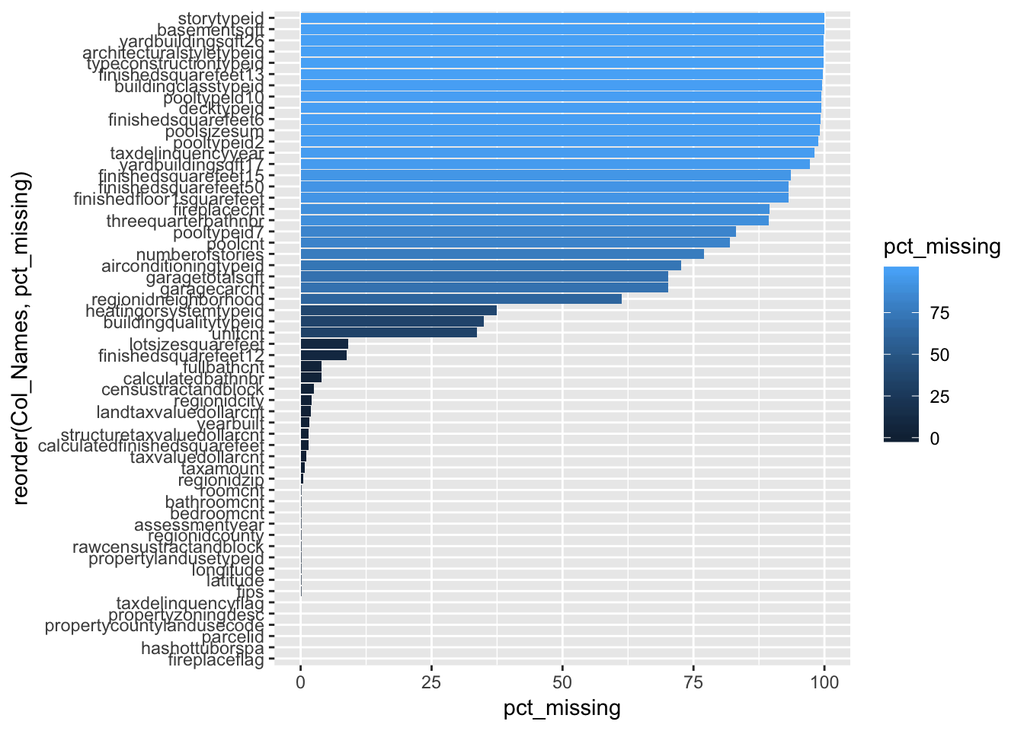

```r
library("data.table")

missdata.df <- as.data.frame(missing.bycol)
setDT(missdata.df, keep.rownames = TRUE)
names(missdata.df) <- c('Col_Names', 'pct_missing')


g<-ggplot(data = missdata.df , aes(x= reorder(Col_Names, pct_missing), y=pct_missing)) + geom_bar(stat = "identity",aes(fill = pct_missing), position = position_stack(reverse= TRUE)) + coord_flip()
g
```

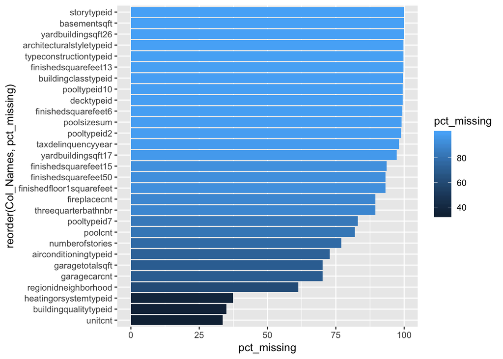

```r
#visulization the columns more than 20% missing value
#head(missdata.df)
missdata.df20 <- missdata.df %>% filter (pct_missing>=20)
g1<-ggplot(data = missdata.df20  , aes(x= reorder(Col_Names, pct_missing), y=pct_missing)) + geom_bar(stat = "identity",aes(fill = pct_missing), position = position_stack(reverse= TRUE)) + coord_flip()
g1
```

#### In metabolomics, missing values that exist in more than 20% of samples may be removed from the data, which is called “80% rule”

```r
# remove variables with missing > 20%
mis_prop <- sapply(properties, function(x) sum(is.na(x))/length(x))
var_rm <- names(mis_prop)[mis_prop > 1 - 0.8]
var_rm
```

```
##  [1] "airconditioningtypeid"    "architecturalstyletypeid"
##  [3] "basementsqft"             "buildingclasstypeid"
##  [5] "buildingqualitytypeid"    "decktypeid"
##  [7] "finishedfloor1squarefeet" "finishedsquarefeet13"
##  [9] "finishedsquarefeet15"     "finishedsquarefeet50"
## [11] "finishedsquarefeet6"      "fireplacecnt"
## [13] "garagecarcnt"             "garagetotalsqft"
## [15] "heatingorsystemtypeid"    "poolcnt"
## [17] "poolsizesum"              "pooltypeid10"
## [19] "pooltypeid2"              "pooltypeid7"
## [21] "regionidneighborhood"     "storytypeid"
## [23] "threequarterbathnbr"      "typeconstructiontypeid"
## [25] "unitcnt"                  "yardbuildingsqft17"
## [27] "yardbuildingsqft26"       "numberofstories"
## [29] "taxdelinquencyyear"
```

```r
miss_rate <- as.data.frame(unlist(mis_prop), stringsAsFactors=FALSE)

miss_rate <- setDT(miss_rate, keep.rownames = TRUE)[]
names(miss_rate) <- c('ColName', "Missing_Perc")
miss_rate[order(miss_rate$Missing_Perc),]
```

```
##                          ColName Missing_Perc
##  1:                     parcelid 0.0000000000
##  2:               hashottuborspa 0.0000000000
##  3:    propertycountylandusecode 0.0000000000
##  4:           propertyzoningdesc 0.0000000000
##  5:                fireplaceflag 0.0000000000
##  6:           taxdelinquencyflag 0.0000000000
##  7:                         fips 0.0009821732
##  8:                     latitude 0.0009821732
##  9:                    longitude 0.0009821732
## 10:        propertylandusetypeid 0.0009821732
## 11:       rawcensustractandblock 0.0009821732
## 12:               regionidcounty 0.0009821732
## 13:               assessmentyear 0.0009825081
## 14:                   bedroomcnt 0.0009865279
```

[output cut: 45 more lines]

```r
df_rm_na <-properties[, !colnames(properties) %in% var_rm]

dim(df_rm_na)
```

```
## [1] 2985217      29
```

```r
str(df_rm_na)
```

```
## 'data.frame':    2985217 obs. of  29 variables:
##  $ parcelid                    : int  10754147 10759547 10843547 10859147 10879947 10898347 10933547 10940747 10954547 10976347 ...
##  $ bathroomcnt                 : num  0 0 0 0 0 0 0 0 0 0 ...
##  $ bedroomcnt                  : num  0 0 0 0 0 0 0 0 0 0 ...
##  $ calculatedbathnbr           : num  NA NA NA NA NA NA NA NA NA NA ...
##  $ calculatedfinishedsquarefeet: num  NA NA 73026 5068 1776 ...
##  $ finishedsquarefeet12        : int  NA NA NA NA NA NA NA NA NA NA ...
##  $ fips                        : int  6037 6037 6037 6037 6037 6037 6037 6037 6037 6037 ...
##  $ fullbathcnt                 : int  NA NA NA NA NA NA NA NA NA NA ...
##  $ hashottuborspa              : Factor w/ 2 levels "","true": 1 1 1 1 1 1 1 1 1 1 ...
##  $ latitude                    : int  34144442 34140430 33989359 34148863 34194168 34171873 34131929 34171345 34218210 34289776 ...
##  $ longitude                   : int  -118654084 -118625364 -118394633 -118437206 -118385816 -118380906 -118351474 -118314900 -118331311 -118432085 ...
##  $ lotsizesquarefeet           : num  85768 4083 63085 7521 8512 ...
##  $ propertycountylandusecode   : Factor w/ 235 levels "","0","010","0100",..: 14 12 150 150 162 162 22 162 14 162 ...
##  $ propertylandusetypeid       : int  269 261 47 47 31 31 260 31 269 31 ...
##  $ propertyzoningdesc          : Factor w/ 5652 levels "","**AHRP","#12",..: 1 2166 1821 1821 1843 1825 1821 574 598 4819 ...
##  $ rawcensustractandblock      : num  60378002 60378001 60377030 60371412 60371232 ...
##  $ regionidcity                : int  37688 37688 51617 12447 12447 12447 12447 396054 396054 47547 ...
##  $ regionidcounty              : int  3101 3101 3101 3101 3101 3101 3101 3101 3101 3101 ...
##  $ regionidzip                 : int  96337 96337 96095 96424 96450 96446 96049 96434 96436 96366 ...
##  $ roomcnt                     : num  0 0 0 0 0 0 0 0 0 0 ...
##  $ yearbuilt                   : num  NA NA 1959 1948 1947 ...
##  $ fireplaceflag               : Factor w/ 2 levels "","true": 1 1 1 1 1 1 1 1 1 1 ...
##  $ structuretaxvaluedollarcnt  : num  NA NA 660680 580059 196751 ...
##  $ taxvaluedollarcnt           : num  9 27516 1434941 1174475 440101 ...
##  $ assessmentyear              : int  2016 2015 2016 2016 2016 2016 2016 2016 2016 2016 ...
##  $ landtaxvaluedollarcnt       : num  9 27516 774261 594416 243350 ...
##  $ taxamount                   : num  NA NA 20800 14558 5725 ...
##  $ taxdelinquencyflag          : Factor w/ 2 levels "","Y": 1 1 1 1 1 1 1 1 1 1 ...
##  $ censustractandblock         : num  NA NA NA NA NA NA NA NA NA NA ...
```

#### load train data from sqlite db

```r
target_df <- merge.data.frame(traindf, df_rm_na,by="parcelid")
```

```r
str(target_df)
```

```
## 'data.frame':    77613 obs. of  31 variables:
##  $ parcelid                    : int  10711855 10711877 10711888 10711910 10711923 10711945 10711956 10711995 10712005 10712007 ...
##  $ logerror                    : num  -0.00736 0.02107 0.07717 -0.04124 -0.0095 ...
##  $ transactiondate             : chr  "2017-07-07" "2017-08-29" "2017-04-04" "2017-03-17" ...
##  $ bathroomcnt                 : num  2 2 2 2 2 2 3 2 2 2 ...
##  $ bedroomcnt                  : num  3 4 4 3 4 3 3 4 3 3 ...
##  $ calculatedbathnbr           : num  2 2 2 2 2 2 3 2 2 2 ...
##  $ calculatedfinishedsquarefeet: num  2107 1882 1882 1477 1918 ...
##  $ finishedsquarefeet12        : int  2107 1882 1882 1477 1918 2031 1678 1882 1709 1639 ...
##  $ fips                        : int  6037 6037 6037 6037 6037 6037 6037 6037 6037 6037 ...
##  $ fullbathcnt                 : int  2 2 2 2 2 2 3 2 2 2 ...
##  $ hashottuborspa              : Factor w/ 2 levels "","true": 1 1 1 1 1 1 1 1 1 1 ...
##  $ latitude                    : int  34222559 34220261 34222491 34221864 34220619 34220664 34224186 34223458 34224173 34224530 ...
##  $ longitude                   : int  -118617387 -118616409 -118616854 -118615739 -118615253 -118614105 -118614125 -118617964 -118618635 -118618636 ...
##  $ lotsizesquarefeet           : num  9158 9035 9800 11285 11239 ...
```

[output cut: 17 more lines]

## Deal with missing value and add feature

```r
# life of property
summary(target_df$yearbuilt)
```

```
##    Min. 1st Qu.  Median    Mean 3rd Qu.    Max.    NA's
##    1824    1953    1970    1969    1987    2016     304
```

```r
# Draw with black outline, white fill
#ggplot(dat, aes(x=yearbuilt)) +
#    geom_histogram(binwidth=.5, colour="black", fill="white")

### fill NA with median number
target_df$yearbuilt[is.na(target_df$yearbuilt)]<-median(target_df$yearbuilt,na.rm=T)
```

```r
summary(target_df$yearbuilt)
```

```
##    Min. 1st Qu.  Median    Mean 3rd Qu.    Max.
##    1824    1953    1970    1969    1987    2016
```

### convert Non numeric columns to such as propertylandusetypeid , fips to category data

```r
target_df$propertylandusetypeid<-factor(target_df$propertylandusetypeid)
target_df$fips <- factor (target_df$fips)
```

### deal with data with yes or no answers columns

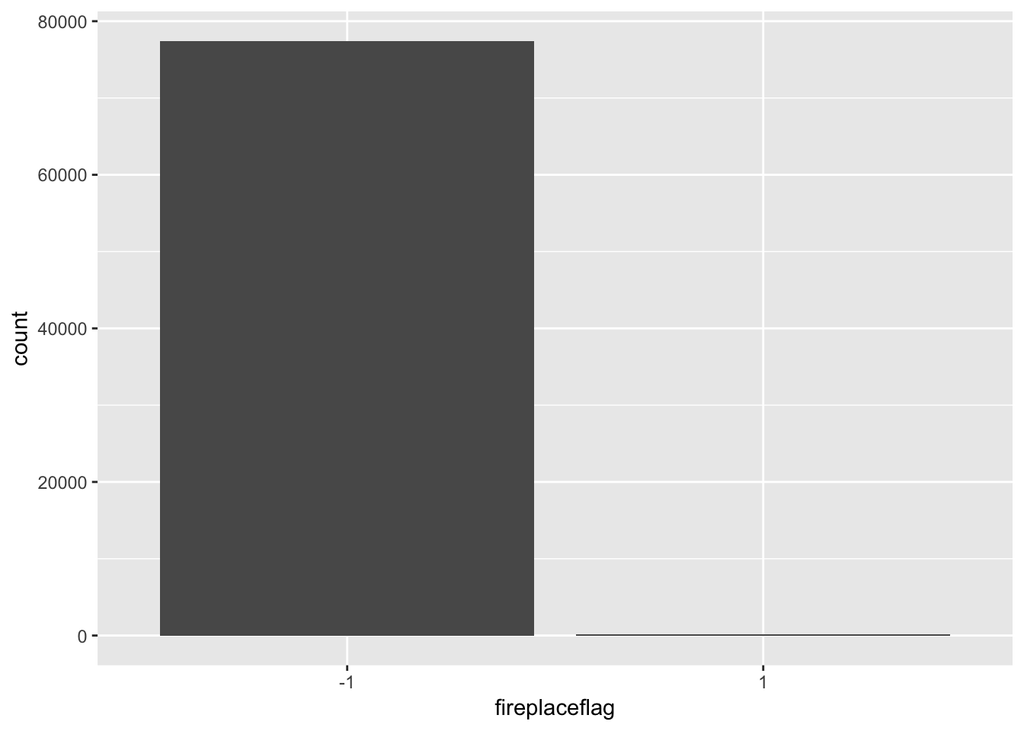

```r
flagColClean <- function(emp)
{  emp<- as.character(emp)
if (emp=="NA"  | emp =="")
{

    return (-1)
}

else
{
    return (1)
}

}

target_df$fireplaceflag<- sapply( target_df$fireplaceflag, flagColClean)
target_df$fireplaceflag<- factor( target_df$fireplaceflag )
g3 <-  ggplot(target_df, aes(fireplaceflag)) +geom_bar()
g3
```

```r
flagcol <- target_df %>% select (contains('flag'))
summary(flagcol)
```

```
##  fireplaceflag taxdelinquencyflag
##  -1:77441       :74713
##  1 :  172      Y: 2900
```

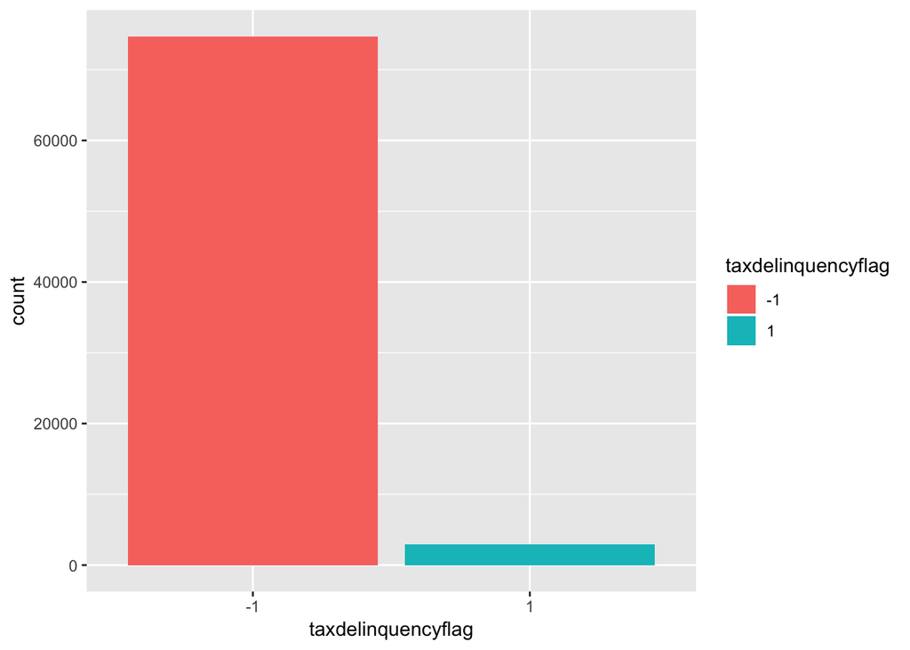

```r
target_df$taxdelinquencyflag<- sapply( target_df$taxdelinquencyflag, flagColClean)
target_df$taxdelinquencyflag<- factor( target_df$taxdelinquencyflag )
g4 <-  ggplot(target_df, aes(taxdelinquencyflag)) +geom_bar(aes(fill=taxdelinquencyflag))
g4
```

### deal with date data (Extract Month from date and convert to factor variable)

```r
target_df$transactionMonth <- as.factor (month(as.POSIXlt(
  target_df$transactiondate, format="%Y-%m-%d")))
```

### visualize tax related columns

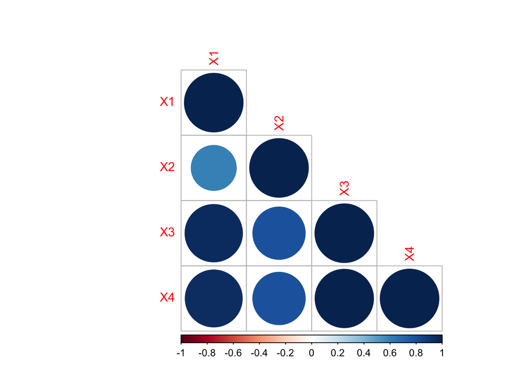

```r
## check the relationship between tax releated variables
tax<- data.frame(cbind(target_df$landtaxvaluedollarcnt,target_df$structuretaxvaluedollarcnt,
                       target_df$taxvaluedollarcnt,target_df$taxamount))
corrplot(cor(tax, use="complete.obs"), type="lower")
```

```r
#corrplot(cor(tax, use="complete.obs"), type="lower")
```

#### get unique value per parceid

```r
## extact numeric volue data
target_df <- target_df %>% distinct( parcelid  , .keep_all = TRUE)
rownames(target_df) <- target_df$parcelid
target_df <- target_df [,-1]
```

```r
summary(target_df$logerror)
```

```
##      Min.   1st Qu.    Median      Mean   3rd Qu.      Max.
## -4.655420 -0.024154  0.006728  0.016861  0.039311  5.262999
```

```r
#remove columns with NA
target_df2 <- target_df[complete.cases(target_df), ]
summary(target_df2)
```

```
##     logerror         transactiondate     bathroomcnt       bedroomcnt
##  Min.   :-4.655420   Length:64090       Min.   : 1.000   Min.   : 0.000
##  1st Qu.:-0.024032   Class :character   1st Qu.: 2.000   1st Qu.: 2.000
##  Median : 0.006955   Mode  :character   Median : 2.000   Median : 3.000
##  Mean   : 0.017405                      Mean   : 2.292   Mean   : 3.094
##  3rd Qu.: 0.039543                      3rd Qu.: 3.000   3rd Qu.: 4.000
##  Max.   : 5.262999                      Max.   :13.000   Max.   :11.000
##
##  calculatedbathnbr calculatedfinishedsquarefeet finishedsquarefeet12
##  Min.   : 1.000    Min.   :  152                Min.   :  152
##  1st Qu.: 2.000    1st Qu.: 1200                1st Qu.: 1200
##  Median : 2.000    Median : 1555                Median : 1555
##  Mean   : 2.292    Mean   : 1798                Mean   : 1798
##  3rd Qu.: 3.000    3rd Qu.: 2127                3rd Qu.: 2127
##  Max.   :13.000    Max.   :21929                Max.   :21929
##
##    fips        fullbathcnt     hashottuborspa    latitude
##  6037:45139   Min.   : 1.000       :62645     Min.   :33339527
##  6059:13859   1st Qu.: 2.000   true: 1445     1st Qu.:33843555
##  6111: 5092   Median : 2.000                  Median :34045614
##               Mean   : 2.237                  Mean   :34032257
##               3rd Qu.: 3.000                  3rd Qu.:34183500
##               Max.   :13.000                  Max.   :34818767
##
##    longitude          lotsizesquarefeet propertycountylandusecode
##  Min.   :-119475265   Min.   :    236   0100   :25946
##  1st Qu.:-118429000   1st Qu.:   5746   122    :12498
##  Median :-118197492   Median :   7260   010C   : 8067
##  Mean   :-118224899   Mean   :  30545   0101   : 6147
##  3rd Qu.:-117966663   3rd Qu.:  12234   1111   : 3339
##  Max.   :-117572338   Max.   :6971010   010E   : 1938
##                                         (Other): 6155
##  propertylandusetypeid propertyzoningdesc rawcensustractandblock
##  261    :50585                :19126      Min.   :60371011
##  266    :11316         LAR1   : 6441      1st Qu.:60373005
##  269    : 1767         LAR3   : 2050      Median :60375723
##  265    :  311         LARS   : 1385      Mean   :60479663
##  263    :   58         LBR1N  : 1141      3rd Qu.:60590320
##  267    :   29         SCUR2  :  843      Max.   :61110091
##  (Other):   24         (Other):33104
```

[output cut: 25 more lines]

```
##  Min.   :    19.92   -1:61660           Min.   :6.037e+13
##  1st Qu.:  2659.21   1 : 2430           1st Qu.:6.037e+13
##  Median :  4424.40                      Median :6.038e+13
##  Mean   :  6019.01                      Mean   :6.049e+13
##  3rd Qu.:  6903.78                      3rd Qu.:6.059e+13
##  Max.   :290998.06                      Max.   :4.830e+14
##
##  transactionMonth
##  6      : 9540
##  5      : 8679
##  8      : 8138
##  7      : 7850
##  3      : 7705
##  4      : 7176
##  (Other):15002
```

```r
### assessmentyear is constant variable , remove from the dataset
  target_df2 <- target_df2 %>% select (-contains('assessmentyear'))
```

```r
 # Add Feature
    #
    # life of property
   target_df2$N.HousYear = 2018 -target_df2$yearbuilt

  # target_df2$N.calculatedfinishedsquarefeet =target_df2$finishedsquarefeet12

    # error in calculation of the finished living area of home
   #target_df2$N.LivingAreaError =target_df2$calculatedfinishedsquarefeet /target_df2$finishedsquarefeet12

    # proportion of living area
   target_df2$N.LivingAreaProp =target_df2$calculatedfinishedsquarefeet /target_df2$lotsizesquarefeet

    # Amout of extra space
   target_df2$N.ExtraSpace =target_df2$lotsizesquarefeet -target_df2$calculatedfinishedsquarefeet

    # Total number of bed rooms
   target_df2$N.TotalRooms =target_df2$bathroomcnt +target_df2$bedroomcnt

    # Average room size
    target_df2$N.AvRoomSize  =target_df2$calculatedfinishedsquarefeet/target_df2$N.TotalRooms

    # Number of Extra rooms
   target_df2$N.ExtraRooms =target_df2$roomcnt -target_df2$N.TotalRooms

    # Ratio of the built structure value to land area
   target_df2$N.ValueProp =target_df2$structuretaxvaluedollarcnt /target_df2$landtaxvaluedollarcnt
```

```r
### Deal with latitude and longitude data
 target_df2$latitude = as.numeric(target_df2$latitude)
 target_df2$longitude= as.numeric(target_df2$longitude)
   target_df2$N.location  = target_df2$latitude +target_df2$longitude
   target_df2$N.location2  = as.numeric(target_df2$latitude/target_df2$longitude )
    #properties $N-location-2round  =target_df $N-location-2 .round(-4)

    # Ratio of tax of property over parcel
   target_df2$N.ValueRatio  =target_df2$taxvaluedollarcnt /target_df2$taxamount

    # TotalTaxScore
   target_df2$N.TaxScore  =target_df2$taxvaluedollarcnt*target_df2$taxamount

    # polnomials of tax delinquency year
  # target_df$N.taxdelinquencyyear2 =target_df$taxdelinquencyyear ** 2
  # target_df$N.taxdelinquencyyear3 =target_df$taxdelinquencyyear  ** 3

    # Length of time since unpaid taxes
  # target_df$N.live = 2018 -target_df$taxl
  #Number oftarget_df in the city
   city_count  <-  count(target_df2, regionidcity)
    names(city_count) <- c('regionidcity','City_Count')
  # city_countc
  target_df2<-merge(x=target_df2,y=city_count,by="regionidcity" ,all=TRUE)


#   target_df$N.city_count <-  count ( target_df, target_df$regionidcity)
  # target_df$N.city_count  =target_df$regionidcity.map(city_count)

 # Number of propertities in the county

 county_count  <-  count(target_df2, regionidcounty)
names(county_count) <- c('regionidcounty','County_Count')
  # city_countc
  target_df2<-merge(x=target_df2,y=county_count,by="regionidcounty" ,all=TRUE)

   # Number of properties in the zip

zip_count  <-  count(target_df2, regionidzip)
names(zip_count) <- c('regionidzip','Zip_Count')
target_df2<-merge(x=target_df2,y= zip_count  ,by="regionidzip" ,all=TRUE)
```

#### Finalize features

```r
## remove columns with free text
target_df2<- target_df2 %>% select (-contains('propertyzoningdesc'), -contains('itude'), -starts_with('year'),-contains('itude'), -contains('rowcensus'),-contains('transactiondate'), -contains('regionid'), -contains('assessmentyear'))
## list all datatype of datafame
split(names(target_df2),sapply(target_df2, function(x) paste(class(x), collapse=" ")))
```

```
## $factor
## [1] "fips"                      "hashottuborspa"
## [3] "propertycountylandusecode" "propertylandusetypeid"
## [5] "fireplaceflag"             "taxdelinquencyflag"
## [7] "transactionMonth"
##
## $integer
## [1] "finishedsquarefeet12" "fullbathcnt"          "City_Count"
## [4] "County_Count"         "Zip_Count"
##
## $numeric
##  [1] "logerror"                     "bathroomcnt"
##  [3] "bedroomcnt"                   "calculatedbathnbr"
##  [5] "calculatedfinishedsquarefeet" "lotsizesquarefeet"
##  [7] "rawcensustractandblock"       "roomcnt"
##  [9] "structuretaxvaluedollarcnt"   "taxvaluedollarcnt"
## [11] "landtaxvaluedollarcnt"        "taxamount"
## [13] "censustractandblock"          "N.HousYear"
## [15] "N.LivingAreaProp"             "N.ExtraSpace"
## [17] "N.TotalRooms"                 "N.AvRoomSize"
## [19] "N.ExtraRooms"                 "N.ValueProp"
## [21] "N.location"                   "N.location2"
## [23] "N.ValueRatio"                 "N.TaxScore"
```

### Normalize Numeric Data

```r
normfun <- function(x) (x - min(x))/(max(x)-min(x))

numcol <- sapply(target_df2,is.numeric)
numcol['logerror'] <- FALSE
numcol ['rawcensustractandblock']
```

```
## rawcensustractandblock
##                   TRUE
```

```r
numcol
```

```
##                     logerror                  bathroomcnt
##                        FALSE                         TRUE
##                   bedroomcnt            calculatedbathnbr
##                         TRUE                         TRUE
## calculatedfinishedsquarefeet         finishedsquarefeet12
##                         TRUE                         TRUE
##                         fips                  fullbathcnt
##                        FALSE                         TRUE
##               hashottuborspa            lotsizesquarefeet
##                        FALSE                         TRUE
##    propertycountylandusecode        propertylandusetypeid
##                        FALSE                        FALSE
##       rawcensustractandblock                      roomcnt
##                         TRUE                         TRUE
##                fireplaceflag   structuretaxvaluedollarcnt
##                        FALSE                         TRUE
##            taxvaluedollarcnt        landtaxvaluedollarcnt
##                         TRUE                         TRUE
##                    taxamount           taxdelinquencyflag
##                         TRUE                        FALSE
##          censustractandblock             transactionMonth
##                         TRUE                        FALSE
##                   N.HousYear             N.LivingAreaProp
##                         TRUE                         TRUE
##                 N.ExtraSpace                 N.TotalRooms
##                         TRUE                         TRUE
##                 N.AvRoomSize                 N.ExtraRooms
##                         TRUE                         TRUE
##                  N.ValueProp                   N.location
##                         TRUE                         TRUE
##                  N.location2                 N.ValueRatio
##                         TRUE                         TRUE
##                   N.TaxScore                   City_Count
##                         TRUE                         TRUE
##                 County_Count                    Zip_Count
##                         TRUE                         TRUE
```

```r
numcol_df<- as.data.frame(numcol)
numcol_df <- setDT(numcol_df, keep.rownames = TRUE)[]
names(numcol_df) <- c ("ColName","IsNumeric")
Numeric_col <- numcol_df %>% filter (IsNumeric==TRUE)
Numeric_col <- Numeric_col$ColName

for (i in Numeric_col)
{

    {target_df2[i] <- lapply(target_df2[i], normfun)}

}
```

### deal with categorical data

```r
levels(target_df2$fips)
```

```
## [1] "6037" "6059" "6111"
```

```r
### change fips categor dota to numeric value
#summary(target_df2$fips)
target_df2$fips = as.numeric(factor(target_df2$fips,
                                      levels = c("6037", "6059" ,"6111"),
                                      labels = c(1, 2, 3)))
```

```r
summary(target_df2$fips)
```

```
##    Min. 1st Qu.  Median    Mean 3rd Qu.    Max.
##   1.000   1.000   1.000   1.375   2.000   3.000
```

```r
levels(target_df2$hashottuborspa)
```

```
## [1] ""     "true"
```

```r
target_df2$hashottuborspa = as.numeric(factor(target_df2$hashottuborspa,
                                      levels = c(""   ,  "true"),
                                      labels = c(-1, 1)))
```

```r
summary(target_df2$hashottuborspa)
```

```
##    Min. 1st Qu.  Median    Mean 3rd Qu.    Max.
##   1.000   1.000   1.000   1.023   1.000   2.000
```

### convert propertycountylandusecode

```r
summary(target_df2$propertycountylandusecode)
```

```
##    0100     122    010C    0101    1111    010E    010D       1    1110
##   25946   12498    8067    6147    3339    1938    1767    1002     998
##    1129    0104      34    1128    012C    01DC    01HC    0103    010G
##     427     357     355     311     200     167      98      86      78
##    010H    0108    0700    010M    010F    010V    0109    1116    0110
##      64      54      49      48      29       9       8       7       6
##    0113    1117      38    0102    1120    0105    0111    070D    0114
##       6       6       4       3       3       2       2       2       1
##    012D    0130    0131    0133    0200    1112               0     010
##       1       1       1       1       1       1       0       0       0
##    0106    010L    010T    010X    010Y    0115    0118    011C    0120
##       0       0       0       0       0       0       0       0       0
##    0121    0122    0123    012E    012G    0132    0134    0140    0141
##       0       0       0       0       0       0       0       0       0
##    014D     01C    01DD    01DE    01DG    01HE    01MC    01T0    0201
##       0       0       0       0       0       0       0       0       0
##    0202    0203    0204    0208    0209    020A    020C    020D    020E
##       0       0       0       0       0       0       0       0       0
##    020G    020M    020V    020X    0210    0220    0230    02G0    0300
##       0       0       0       0       0       0       0       0       0
##    0301    0303    0304    0305    0308    0309    030A    030B    030C
##       0       0       0       0       0       0       0       0       0
## (Other)
##       0
```

### deal with some categorical variables with multiple levels

```r
landCodeClean <- function(emp)
{  emp<- as.character(emp)
if (emp=="0100" )
{

    return (1)
}

else if (emp=="22")
{
    return (2)
}

else if (emp=="010C")
{
    return (3)
}
else
{
  return (4)
}

}



target_df2$propertycountylandusecode<- sapply( target_df2$propertycountylandusecode, landCodeClean)
target_df2$propertycountylandusecode<- factor(target_df2$propertycountylandusecode )
```

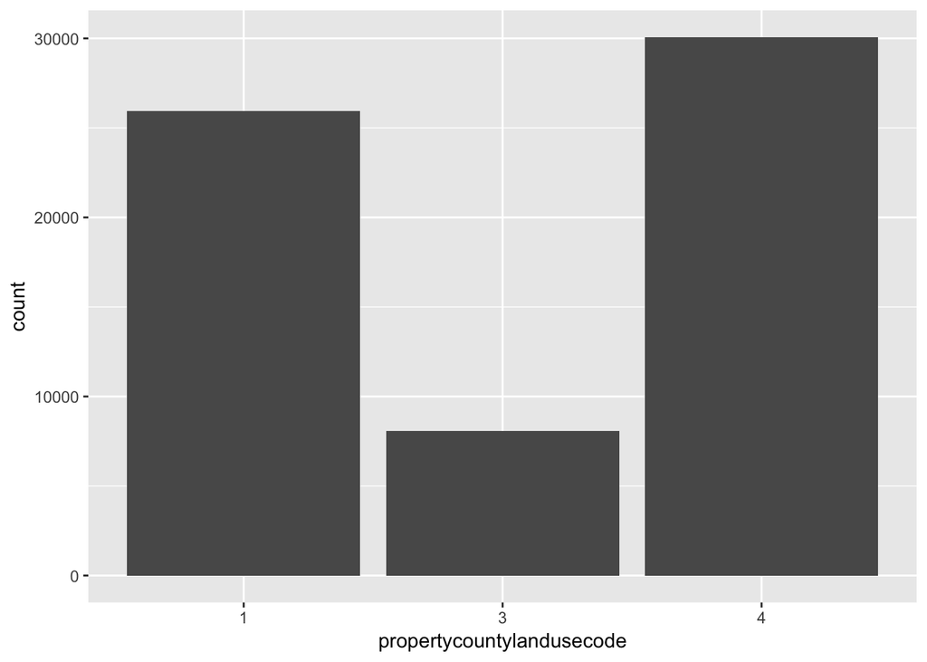

```r
g5 <-  ggplot(target_df2, aes(propertycountylandusecode)) +geom_bar()
g5
```

```r
summary(target_df2$propertycountylandusecode)
```

```
##     1     3     4
## 25946  8067 30077
```

```r
summary(target_df2$propertylandusetypeid )
```

```
##    31   246   247   248   260   261   263   264   265   266   267   269
##     0     5     0     0     9 50585    58     1   311 11316    29  1767
##   275
##     9
```

```r
propertypeClean <- function(emp)
{  emp<- as.character(emp)
if (emp=="261" )
{

    return (1)
}

else if (emp=="266")
{
    return (2)
}

else if (emp=="269")
{
    return (3)
}
else
{
  return (4)
}

}


target_df2$propertylandusetypeid<- sapply( target_df2$propertylandusetypeid, propertypeClean)
target_df2$propertylandusetypeid<- factor( target_df2$propertylandusetypeid )
```

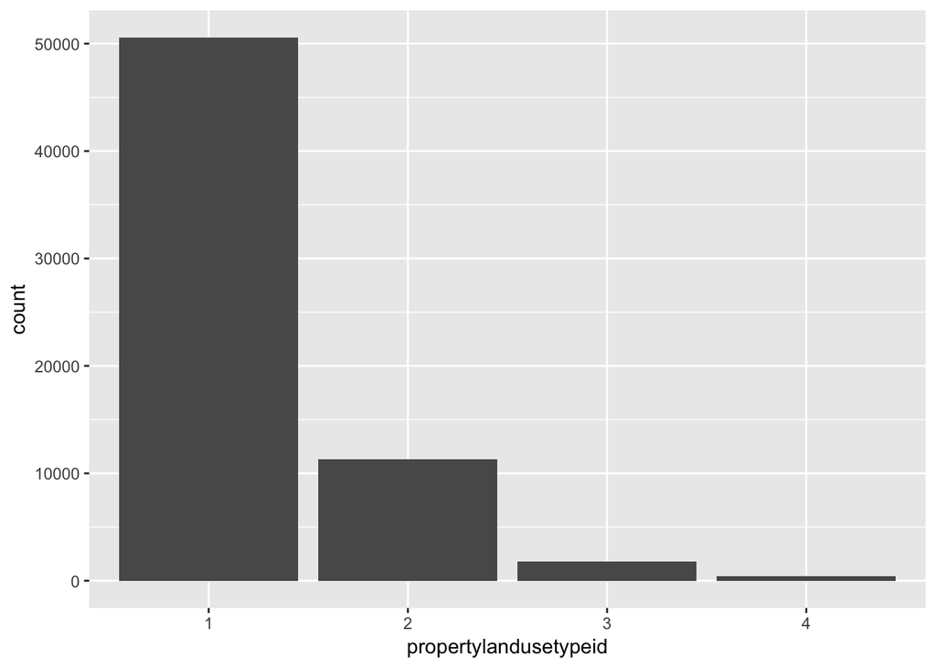

```r
g5 <-  ggplot(target_df2, aes(propertylandusetypeid)) +geom_bar()
g5
```

```r
### Finalized_dataset
dataset <- target_df2

dim(dataset)
```

```
## [1] 64090    36
```

```r
#dataset$propertycountylandusecode <- as.numeric(dataset$propertycountylandusecode)
#dataset$propertylandusetypeid <- as.numeric(dataset$propertylandusetypeid)
#dataset$fireplaceflag <- as.numeric(dataset$fireplaceflag)
#dataset$taxdelinquencyflag <- as.numeric(dataset$taxdelinquencyflag)
#dataset$transactionMonth <- as.numeric(dataset$tra)
```

```r
str(dataset)
```

```
## 'data.frame':    64090 obs. of  36 variables:
##  $ logerror                    : num  0.0628 -0.0316 0.1341 -0.0232 0.0136 ...
##  $ bathroomcnt                 : num  0 0.0833 0.0833 0 0.0833 ...
##  $ bedroomcnt                  : num  0.182 0.273 0.273 0.273 0.182 ...
##  $ calculatedbathnbr           : num  0 0.0833 0.0833 0 0.0833 ...
##  $ calculatedfinishedsquarefeet: num  0.0325 0.033 0.038 0.0397 0.0336 ...
##  $ finishedsquarefeet12        : num  0.0325 0.033 0.038 0.0397 0.0336 ...
##  $ fips                        : num  1 1 1 1 1 1 1 1 1 1 ...
##  $ fullbathcnt                 : num  0 0.0833 0.0833 0 0.0833 ...
##  $ hashottuborspa              : num  1 1 1 1 1 1 1 1 1 1 ...
##  $ lotsizesquarefeet           : num  0.000747 0.000515 0.000759 0.000704 0.000698 ...
##  $ propertycountylandusecode   : Factor w/ 3 levels "1","3","4": 1 1 1 1 1 1 1 1 1 1 ...
##  $ propertylandusetypeid       : Factor w/ 4 levels "1","2","3","4": 1 1 1 1 1 1 1 1 1 1 ...
##  $ rawcensustractandblock      : num  0.00587 0.00587 0.00584 0.00587 0.00187 ...
##  $ roomcnt                     : num  0 0 0 0 0 0 0 0 0 0 ...
```

[output cut: 22 more lines]

## USE H2O Analysis dataset

#### h2o pakage : H2O is a powerful and efficient java-based interface that allows for local and cluster-based deployment.

- Stochastic GBM with column and row sampling (per split and per tree) for better generalization.
- Support for exponential families (Poisson, Gamma, Tweedie) and loss functions in addition to binomial (Bernoulli), Gaussian and multinomial distributions, such as Quantile regression (including Laplace).
- Grid search for hyperparameter optimization and model selection.

```r
#install.packages('h2o')
######################################
# Setup h2o
######################################
library(h2o)
h2o.init(nthreads = -1, max_mem_size = "8g")
```

```
##
## H2O is not running yet, starting it now...
##
## Note:  In case of errors look at the following log files:
##     /var/folders/p4/1y644xmn47ldjq37jlmxx_gc0000gn/T//RtmpfMEPPN/h2o_hongxin_started_from_r.out
##     /var/folders/p4/1y644xmn47ldjq37jlmxx_gc0000gn/T//RtmpfMEPPN/h2o_hongxin_started_from_r.err
##
##
## Starting H2O JVM and connecting: .. Connection successful!
##
## R is connected to the H2O cluster:
##     H2O cluster uptime:         2 seconds 452 milliseconds
##     H2O cluster timezone:       America/New_York
##     H2O data parsing timezone:  UTC
##     H2O cluster version:        3.20.0.8
##     H2O cluster version age:    2 months and 17 days
##     H2O cluster name:           H2O_started_from_R_hongxin_ggv429
##     H2O cluster total nodes:    1
##     H2O cluster total memory:   7.11 GB
##     H2O cluster total cores:    8
##     H2O cluster allowed cores:  8
##     H2O cluster healthy:        TRUE
##     H2O Connection ip:          localhost
##     H2O Connection port:        54321
##     H2O Connection proxy:       NA
##     H2O Internal Security:      FALSE
##     H2O API Extensions:         XGBoost, Algos, AutoML, Core V3, Core V4
##     R Version:                  R version 3.5.1 (2018-07-02)
```

```r
###  split dataset  Best approach by using the Gridsearch  (Skipped in the project )

datah2o <- as.h2o(dataset)
splits <- h2o.splitFrame(data = datah2o,
                         ratios = c(0.7, 0.15),  #
                         seed = 1)  #setting a seed will guarantee reproducibility
train <- splits[[1]]
valid <- splits[[2]]
test <- splits[[3]]


# Identify predictors and response
x <- names(train)[which(names(train)!="logerror")]
y <- "logerror"
print(x)
```

```
##  [1] "bathroomcnt"                  "bedroomcnt"
##  [3] "calculatedbathnbr"            "calculatedfinishedsquarefeet"
##  [5] "finishedsquarefeet12"         "fips"
##  [7] "fullbathcnt"                  "hashottuborspa"
##  [9] "lotsizesquarefeet"            "propertycountylandusecode"
## [11] "propertylandusetypeid"        "rawcensustractandblock"
## [13] "roomcnt"                      "fireplaceflag"
## [15] "structuretaxvaluedollarcnt"   "taxvaluedollarcnt"
## [17] "landtaxvaluedollarcnt"        "taxamount"
## [19] "taxdelinquencyflag"           "censustractandblock"
## [21] "transactionMonth"             "N.HousYear"
## [23] "N.LivingAreaProp"             "N.ExtraSpace"
## [25] "N.TotalRooms"                 "N.AvRoomSize"
## [27] "N.ExtraRooms"                 "N.ValueProp"
## [29] "N.location"                   "N.location2"
## [31] "N.ValueRatio"                 "N.TaxScore"
## [33] "City_Count"                   "County_Count"
## [35] "Zip_Count"
```

```r
## Show the dataset
nrow(train)  # 114908
```

```
## [1] 44868
```

```r
nrow(valid) # 24498
```

```
## [1] 9560
```

```r
nrow(test)  # 24581
```

```
## [1] 9662
```

#### Basic implementation by using default parameter

From H2O.ai.com Gradient Boosting Machine (GBM model ) Gradient Boosting Machine (for Regression and Classification) is a forward learning ensemble method. The guiding heuristic is that good predictive results can be obtained through increasingly refined approximations. H2O’s GBM sequentially builds regression trees on all the features of the dataset in a fully distributed way - each tree is built in parallel.

#### Because of the combinatorial explosion, each additional hyperparameter that gets added to our grid search has a huge effect on the time to complete. Consequently, h2o provides an additional grid search path called “RandomDiscrete”, which will jump from one random combination to another and stop once a certain level of improvement has been made, certain amount of time has been exceeded, or a certain amount of models have been ran (or a combination of these have been met).

```r
# library(h2o)
# h2o.init(nthreads = -1, max_mem_size = "8g")
#
#
#
# ###  split dataset  Best approach by using the Gridsearch  (Skipped in the project )
#
# datah2o <- as.h2o(dataset)
# splits <- h2o.splitFrame(data = datah2o,
#                          ratios = c(0.7, 0.15),  #
#                          seed = 1)  #setting a seed will guarantee reproducibility
# train <- splits[[1]]
# valid <- splits[[2]]
# test <- splits[[3]]
#
#
# # Identify predictors and response
# x <- names(train)[which(names(train)!="logerror")]
# y <- "logerror"
# print(x)
```

```r
#gbm.fit <- h2o.gbm(
#  x = x,
#  y = y,
#  training_frame = train,
#  nfolds = 5,
#  ntrees = 5000,
 # stopping_rounds = 10,
 # stopping_tolerance = 0,
 # seed = 123
#)
```

```r
#h2o.varimp_plot(gbm.fit , num_of_features = 15)
#h2o.mae(gbm.fit)
```

```r
#h2o.shutdown()
```

#### Tuning of the model

Tree complexity:ntrees: number of trees to train max_depth: depth of each tree min_rows: Fewest observations allowed in a terminal node Learning rate: learn_rate: rate to descend the loss function gradient learn_rate_annealing: allows you to have a high initial learn_rate, then gradually reduce as trees are added (speeds up training). Adding stochastic nature: sample_rate: row sample rate per tree col_sample_rate: column sample rate per tree (synonymous with xgboost’s colsample_bytree)

```r
h2o.init(nthreads = -1, max_mem_size = "8g")
```

```
##  Connection successful!
##
## R is connected to the H2O cluster:
##     H2O cluster uptime:         9 seconds 996 milliseconds
##     H2O cluster timezone:       America/New_York
##     H2O data parsing timezone:  UTC
##     H2O cluster version:        3.20.0.8
##     H2O cluster version age:    2 months and 17 days
##     H2O cluster name:           H2O_started_from_R_hongxin_ggv429
##     H2O cluster total nodes:    1
##     H2O cluster total memory:   7.06 GB
##     H2O cluster total cores:    8
##     H2O cluster allowed cores:  8
##     H2O cluster healthy:        TRUE
##     H2O Connection ip:          localhost
##     H2O Connection port:        54321
##     H2O Connection proxy:       NA
##     H2O Internal Security:      FALSE
##     H2O API Extensions:         XGBoost, Algos, AutoML, Core V3, Core V4
##     R Version:                  R version 3.5.1 (2018-07-02)
```

```r
###  split dataset  Best approach by using the Gridsearch  (Skipped in the project )

datah2o <- as.h2o(dataset)
splits <- h2o.splitFrame(data = datah2o,
                         ratios = c(0.7, 0.15),  #
                         seed = 1)  #setting a seed will guarantee reproducibility
train <- splits[[1]]
valid <- splits[[2]]
test <- splits[[3]]


# Identify predictors and response
x <- names(train)[which(names(train)!="logerror")]
y <- "logerror"
print(x)
```

```
##  [1] "bathroomcnt"                  "bedroomcnt"
##  [3] "calculatedbathnbr"            "calculatedfinishedsquarefeet"
##  [5] "finishedsquarefeet12"         "fips"
##  [7] "fullbathcnt"                  "hashottuborspa"
##  [9] "lotsizesquarefeet"            "propertycountylandusecode"
## [11] "propertylandusetypeid"        "rawcensustractandblock"
## [13] "roomcnt"                      "fireplaceflag"
## [15] "structuretaxvaluedollarcnt"   "taxvaluedollarcnt"
## [17] "landtaxvaluedollarcnt"        "taxamount"
## [19] "taxdelinquencyflag"           "censustractandblock"
## [21] "transactionMonth"             "N.HousYear"
## [23] "N.LivingAreaProp"             "N.ExtraSpace"
## [25] "N.TotalRooms"                 "N.AvRoomSize"
## [27] "N.ExtraRooms"                 "N.ValueProp"
## [29] "N.location"                   "N.location2"
## [31] "N.ValueRatio"                 "N.TaxScore"
## [33] "City_Count"                   "County_Count"
## [35] "Zip_Count"
```

```r
# random grid search criteria
search_criteria <- list(
  strategy = "RandomDiscrete",
  stopping_metric = "mse",
  stopping_tolerance = 0.005,
  stopping_rounds = 10,
  max_runtime_secs = 60*60
  )
#
# perform grid search
grid <- h2o.grid(
  algorithm = "gbm",
  grid_id = "gbm_grid2",
  x = x,
  y = y,
  training_frame = train,
  validation_frame = valid,
  #hyper_params = hyper_grid,
  search_criteria = search_criteria, # add search criteria
  ntrees = 5000,
  stopping_rounds = 10,
  stopping_tolerance = 0,
  seed = 123
  )
# collect the results and sort by our model performance metric of choice
grid_perf <- h2o.getGrid(
  grid_id = "gbm_grid2",
  sort_by = "mse",
  decreasing = FALSE
  )
grid_perf
```

```
## H2O Grid Details
## ================
##
## Grid ID: gbm_grid2
## Used hyper parameters:
## Number of models: 1
## Number of failed models: 0
##
## Hyper-Parameter Search Summary: ordered by increasing mse
##           model_ids                  mse
## 1 gbm_grid2_model_0 0.030419314115648452
```

#### choose best paramters

```r
best_model_id <- grid_perf@model_ids[[1]]
best_model <- h2o.getModel(best_model_id)
h2o.performance(model = best_model, valid = TRUE)
```

```
## H2ORegressionMetrics: gbm
## ** Reported on validation data. **
##
## MSE:  0.03041931
## RMSE:  0.1744113
## MAE:  0.07118309
## RMSLE:  NaN
## Mean Residual Deviance :  0.03041931
```

```r
grid_summary <- grid_perf@summary_table
grid_summary
```

```
## Hyper-Parameter Search Summary: ordered by increasing mse
##           model_ids                  mse
## 1 gbm_grid2_model_0 0.030419314115648452
```

```r
# train final model
h2o.final <- h2o.gbm(
  x = x,
  y = y,
  training_frame = train,
  nfolds = 5,
  ntrees = 10000,
  learn_rate = 0.05,
  learn_rate_annealing = 0.99,
  max_depth = 5,
  min_rows = 10,
  sample_rate = 0.75,
  col_sample_rate = 1,
  stopping_rounds = 10,
  stopping_tolerance = 0,
  seed = 123
)
###final number of Trees
h2o.final@parameters$ntrees
```

```
## [1] 34
```

```r
### MAE score
h2o.mae(h2o.final, xval = TRUE)
```

```
## [1] 0.06854958
```

```r
### check model performance

h2o.performance(model =best_model , newdata = as.h2o(test))
```

```
## H2ORegressionMetrics: gbm
##
## MSE:  0.02656602
## RMSE:  0.1629909
## MAE:  0.068375
## RMSLE:  NaN
## Mean Residual Deviance :  0.02656602
```

### Visualizing

Variable importance

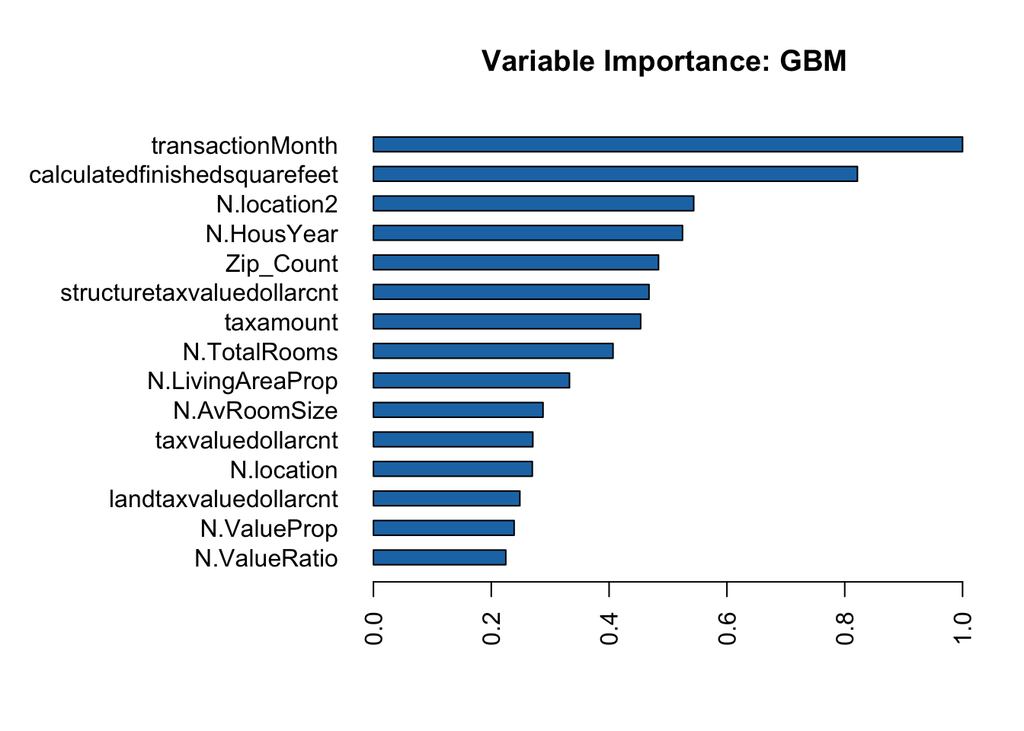

```r
h2o.varimp_plot(h2o.final, num_of_features = 15)
```

```r
#install.packages('lime')


library(lime)
local_obs <- as.data.frame(test[1:2, ])
local_obs$logerror
```

```
## [1] -0.02057943 -0.09055815
```

```r
explainer <- lime(as.data.frame(train), h2o.final)
explanation <- explain(local_obs, explainer, n_features = 5)
```

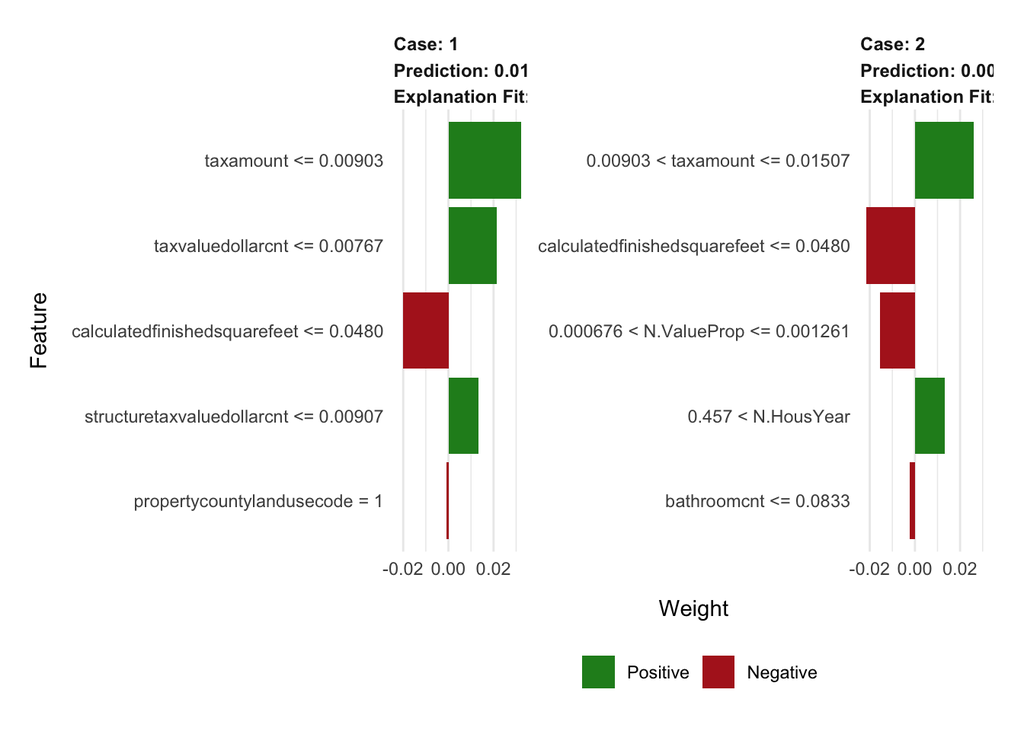

```r
plot_features(explanation)
```

### redicting

Variable importance h2o provides a built function that plots variable importance. It only has one measure of variable importance, relative importance, which measures the average impact each variable has across all the trees on the loss function

```r
h2o.performance(model = h2o.final, newdata = as.h2o(test))
```

```
## H2ORegressionMetrics: gbm
##
## MSE:  0.02642155
## RMSE:  0.1625471
## MAE:  0.067985
## RMSLE:  NaN
## Mean Residual Deviance :  0.02642155
```

```r
# predict with h2o.predict
 h2o.predict(h2o.final, newdata = as.h2o(test))
```

```
##       predict
## 1 0.012689599
## 2 0.003751354
## 3 0.007997316
## 4 0.007997316
## 5 0.065737694
## 6 0.001417370
##
## [9662 rows x 1 column]
```

```r
#h2o.shutdown()
```

###  
GBMs are one of the most powerful ensemble algorithms that are often first-in-class with predictive accuracy. The current model provide MAE score is close to other models published on the website . It can be further improved with grid-search and ensemble method.